# HW1

Caroline Goodman

2022-10-11

```r
##importing files and functions
bos <- read.csv("~/Desktop/MATH 440 - Statistical Learning/BostonHousing.csv")
source("~/Desktop/MATH 440 - Statistical Learning/myfunctions.R")

##remove CAT.MEDV variable
bos <- bos[1:(length(bos)-1)]

##split into training and test set
RNGkind (sample.kind = "Rounding")
set.seed(0) ## set seed so that you get same partition each time
p2 <- partition.2(bos, 0.7) ## creating 70:30 partition
training.data <- p2$data.train
test.data <- p2$data.test
```

## 1. Why should the data be partitioned into training and test sets? What will the training set be used for? What will the test set be used for?

The data should be partitioned into training and test sets because it allows me to develop a more accurate model. A model will be trained using the training set of data. Later, the model will be tested against the test set of data to ensure that the data I collected is applicable in the future and not just the data that the model was trained on.

## Fit a multiple linear regression model to the median house price (MEDV) as a function of CRIM, CHAS, and RM. Write the equation for predicting the median house price using the predictors in the model.

Multiple Linear Regression Model: y = -27.9555 - 0.3004CRIM + 3.1606CHAS + 8.1418RM

```r
#multiple linear regression
mlr <- lm(MEDV~ CRIM+CHAS+RM, data = training.data)
summary(mlr)
```

```
##
## Call:
## lm(formula = MEDV ~ CRIM + CHAS + RM, data = training.data)
##
## Residuals:
##      Min       1Q   Median       3Q      Max
## -23.7466  -3.0210  -0.3493   2.4367  30.1190
##
## Coefficients:
##              Estimate Std. Error t value Pr(>|t|)
## (Intercept) -27.95549    3.08663  -9.057  < 2e-16 ***
## CRIM         -0.30035    0.05041  -5.958 6.22e-09 ***
## CHAS          3.16062    1.23852   2.552   0.0111 *
## RM            8.14180    0.48116  16.921  < 2e-16 ***
## ---
## Signif. codes:  0 '***' 0.001 '**' 0.01 '*' 0.05 '.' 0.1 ' ' 1
##
## Residual standard error: 6.158 on 350 degrees of freedom
## Multiple R-squared:  0.5556, Adjusted R-squared:  0.5518
## F-statistic: 145.9 on 3 and 350 DF,  p-value: < 2.2e-16
```

## Using the estimated regression model, what median house price is predicted for a tract in the Boston area that does not bound the Charles river, has crime rate of 0.1, and where the average number of rooms per house is 6?

The median house price is predicted to be 20.8653.

```r
# median house prediction
x0 <- data.frame(CHAS=0,CRIM = 0.1, RM=6)
predict(mlr, x0)
```

```
##        1
## 20.86527
```

## Fit a linear regression model with all 12 predictors.

$y = 49.5121 - 0.0767CRIM + 0.0497ZN + 0.0285INDUS + 2.8004CHAS - 21.6768NOX + 3.2950RM + 0.0017AGE - 1.7407DIS + 0.3365RAD - 0.0147TAX - 1.0971PTRATIO - 0.5710LSTAT$

```r
# linear regression model with all 12 predictors
mlr2 <- lm(MEDV ~ ., data = training.data)
summary(mlr2)
```

```
##
## Call:
## lm(formula = MEDV ~ ., data = training.data)
##
## Residuals:
##     Min      1Q  Median      3Q     Max
## -13.982  -2.661  -0.494   1.821  25.035
##
## Coefficients:
##               Estimate Std. Error t value Pr(>|t|)
## (Intercept)  49.512143   6.035496   8.203 4.83e-15 ***
## CRIM         -0.076737   0.057380  -1.337  0.18201
## ZN            0.049664   0.017172   2.892  0.00407 **
## INDUS         0.028460   0.073072   0.389  0.69716
## CHAS          2.800445   0.973144   2.878  0.00426 **
## NOX         -21.676831   4.388447  -4.940 1.23e-06 ***
## RM            3.295011   0.505622   6.517 2.58e-10 ***
## AGE           0.001702   0.015745   0.108  0.91397
## DIS          -1.740672   0.250395  -6.952 1.84e-11 ***
## RAD           0.336505   0.085294   3.945 9.68e-05 ***
## TAX          -0.014663   0.004673  -3.138  0.00185 **
## PTRATIO      -1.097086   0.159766  -6.867 3.12e-11 ***
## LSTAT        -0.571030   0.063470  -8.997  < 2e-16 ***
## ---
## Signif. codes:  0 '***' 0.001 '**' 0.01 '*' 0.05 '.' 0.1 ' ' 1
##
## Residual standard error: 4.695 on 341 degrees of freedom
## Multiple R-squared:  0.7483, Adjusted R-squared:  0.7395
## F-statistic:  84.5 on 12 and 341 DF,  p-value: < 2.2e-16
```

##Report the RMSE of the model on test data.

RMSE = 5.1607

```r
# report rmse
yhat = predict(mlr2, newdata=data.frame(test.data))
error.test <- yhat - test.data$MEDV
rmse.test <- sqrt(mean(error.test^2))
rmse.test
```

```
## [1] 5.160716
```

##Is multicollinearity a potential problem for this model? ##Compute the correlation table for the numerical predictors and search for highly correlated pairs.

There is multicollinearity because TAX has a vif value > 10. Looking at the correlation table, RAD and TAX form a pair of highly correlated variables with a correlation value of 0.9248.

```r
# multicollinearity
library(car)
vif(mlr2)
```

```
##      CRIM        ZN     INDUS      CHAS       NOX        RM       AGE       DIS
##  2.450085  2.560984  3.913020  1.071381  4.465330  2.096350  3.062667  4.197164
##       RAD       TAX   PTRATIO     LSTAT
##  9.012800 10.127539  1.960183  3.337286
```

```r
cor(training.data)
```

```
##                CRIM         ZN       INDUS        CHAS        NOX          RM
## CRIM     1.00000000 -0.2371833  0.48763558 -0.05990942  0.4681882 -0.29861487
## ZN      -0.23718328  1.0000000 -0.52913469 -0.04421040 -0.5145751  0.29252138
## INDUS    0.48763558 -0.5291347  1.00000000  0.07707268  0.7673846 -0.35867815
## CHAS    -0.05990942 -0.0442104  0.07707268  1.00000000  0.1117597  0.08620972
## NOX      0.46818825 -0.5145751  0.76738464  0.11175972  1.0000000 -0.29268870
## RM      -0.29861487  0.2925214 -0.35867815  0.08620972 -0.2926887  1.00000000
## AGE      0.41548784 -0.5760285  0.62766091  0.10150916  0.7142481 -0.22488197
## DIS     -0.44043119  0.6888172 -0.69016853 -0.11115454 -0.7629748  0.16606410
## RAD      0.71160788 -0.3215936  0.61930855 -0.02121400  0.5938945 -0.21324941
## TAX      0.67594167 -0.3218268  0.72491042 -0.03600676  0.6506231 -0.28457847
## PTRATIO  0.34138558 -0.4176425  0.38148321 -0.12008878  0.1668138 -0.34552988
## LSTAT    0.57233646 -0.4006209  0.61311234 -0.02383619  0.5895802 -0.63100714
## MEDV    -0.41718899  0.3477742 -0.47713388  0.15926451 -0.4181427  0.70771058
##                AGE        DIS        RAD         TAX    PTRATIO       LSTAT
## CRIM     0.4154878 -0.4404312  0.7116079  0.67594167  0.3413856  0.57233646
## ZN      -0.5760285  0.6888172 -0.3215936 -0.32182680 -0.4176425 -0.40062087
## INDUS    0.6276609 -0.6901685  0.6193086  0.72491042  0.3814832  0.61311234
## CHAS     0.1015092 -0.1111545 -0.0212140 -0.03600676 -0.1200888 -0.02383619
## NOX      0.7142481 -0.7629748  0.5938945  0.65062306  0.1668138  0.58958016
## RM      -0.2248820  0.1660641 -0.2132494 -0.28457847 -0.3455299 -0.63100714
## AGE      1.0000000 -0.7355808  0.4528428  0.48553959  0.2870676  0.60939448
## DIS     -0.7355808  1.0000000 -0.4893552 -0.52081948 -0.2327701 -0.49503035
## RAD      0.4528428 -0.4893552  1.0000000  0.92475405  0.4862224  0.50572728
## TAX      0.4855396 -0.5208195  0.9247540  1.00000000  0.4671189  0.56453745
## PTRATIO  0.2870676 -0.2327701  0.4862224  0.46711891  1.0000000  0.35907482
## LSTAT    0.6093945 -0.4950303  0.5057273  0.56453745  0.3590748  1.00000000
## MEDV    -0.3782071  0.2220908 -0.3829450 -0.46785223 -0.5097599 -0.73696940
##               MEDV
## CRIM    -0.4171890
## ZN       0.3477742
## INDUS   -0.4771339
## CHAS     0.1592645
## NOX     -0.4181427
## RM       0.7077106
## AGE     -0.3782071
## DIS      0.2220908
## RAD     -0.3829450
## TAX     -0.4678522
## PTRATIO -0.5097599
## LSTAT   -0.7369694
## MEDV     1.0000000
```

```r
## there is multicollinearity because variables RAD and TAX have high vif values.
## RAD and TAX are highly correlated variables with correlation value = 0.92.
```

## Use stepwise regression with cross validation approach to reduce the number of predictors. How many variables do you have in the final model? Which variables are dropped? Report the RMSE of this model on test data.

There are 9 variables in the final model (ZN, CHAS, NOX, RM, DIS, RAD, TAX, PTRATIO, LSTAT). Variables CRIM, INDUS, and AGE were dropped. RMSE = 5.299994

```r
# stepwise regression with cv approach
library(caret)
## K-fold Cross Validation
# value of K equal to 5
set.seed(0)
train_control <- trainControl(method = "cv",
                              number = 5)

# Fit K-fold CV model
step_kcv <- train(MEDV ~ ., data = training.data,
                 method = "glmStepAIC", trControl = train_control)
```

```
## Start:  AIC=1710.22
## .outcome ~ CRIM + ZN + INDUS + CHAS + NOX + RM + AGE + DIS +
##     RAD + TAX + PTRATIO + LSTAT
##
##           Df Deviance    AIC
## - INDUS    1   6213.1 1708.2
## - AGE      1   6213.1 1708.2
## - CRIM     1   6236.3 1709.3
## <none>         6213.0 1710.2
## - ZN       1   6268.0 1710.7
## - CHAS     1   6294.7 1711.9
## - TAX      1   6336.3 1713.8
## - RAD      1   6413.7 1717.2
## - NOX      1   6618.3 1726.2
## - DIS      1   6926.9 1739.1
## - RM       1   6952.5 1740.2
## - PTRATIO  1   7228.4 1751.2
## - LSTAT    1   7768.8 1771.7
##
## Step:  AIC=1708.22
## .outcome ~ CRIM + ZN + CHAS + NOX + RM + AGE + DIS + RAD + TAX +
##     PTRATIO + LSTAT
##
##           Df Deviance    AIC
## - AGE      1   6213.1 1706.2
## - CRIM     1   6236.6 1707.3
## <none>         6213.1 1708.2
## - ZN       1   6268.1 1708.7
## - CHAS     1   6295.6 1710.0
## - TAX      1   6359.5 1712.8
## - RAD      1   6425.1 1715.8
## - NOX      1   6649.1 1725.5
## - DIS      1   6953.3 1738.2
## - RM       1   6955.5 1738.3
## - PTRATIO  1   7252.0 1750.1
## - LSTAT    1   7790.6 1770.5
##
## Step:  AIC=1706.22
## .outcome ~ CRIM + ZN + CHAS + NOX + RM + DIS + RAD + TAX + PTRATIO +
##     LSTAT
```

[output cut: 343 more lines]

```
## Step:  AIC=2110.39
## .outcome ~ ZN + CHAS + NOX + RM + DIS + RAD + TAX + PTRATIO +
##     LSTAT
##
##           Df Deviance    AIC
## <none>         7561.5 2110.4
## - ZN       1   7722.8 2115.9
## - CHAS     1   7764.6 2117.8
## - TAX      1   7789.3 2118.9
## - RAD      1   7867.9 2122.4
## - NOX      1   8140.0 2134.5
## - RM       1   8586.7 2153.4
## - PTRATIO  1   8607.5 2154.3
## - DIS      1   8720.8 2158.9
## - LSTAT    1   9946.5 2205.4
```

```r
print(step_kcv$finalModel)
```

```
##
## Call:  NULL
##
## Coefficients:
## (Intercept)           ZN         CHAS          NOX           RM          DIS
##    48.39612      0.04550      2.92987    -20.30432      3.34150     -1.70069
##         RAD          TAX      PTRATIO        LSTAT
##     0.28778     -0.01369     -1.07434     -0.58779
##
## Degrees of Freedom: 353 Total (i.e. Null);  344 Residual
## Null Deviance:       29870
## Residual Deviance: 7561  AIC: 2110
```

```r
yhatSW = predict(step_kcv$finalModel, newdata=data.frame(test.data))
error.test <- yhatSW - test.data$MEDV
rmse.test <- sqrt(mean(error.test^2))
rmse.test
```

```
## [1] 5.299994
```

## Use lasso penalty to fit a regularized regression model with cross validation approach. Do the same variables disappear as in stepwise approach? Report the RMSE of the model on test data.

$y = 44.2872 -0.0374CRIM + 0.0379ZN + 2.7516CHAS - 18.7300NOX + 3.4901RM - 1.5318DIS + 0.2128RAD - 0.0092TAX - 1.0439PTRATIO - 0.5685LSTAT$

Only two of the variables that disappeared in the stepwise regression also disappeared in the lasso regression model: INDUS and AGE. The CRIM variable disappears in the stepwise approach, but not the lasso approach.

RMSE = 5.14288

```r
# lasso
library(glmnet)
```

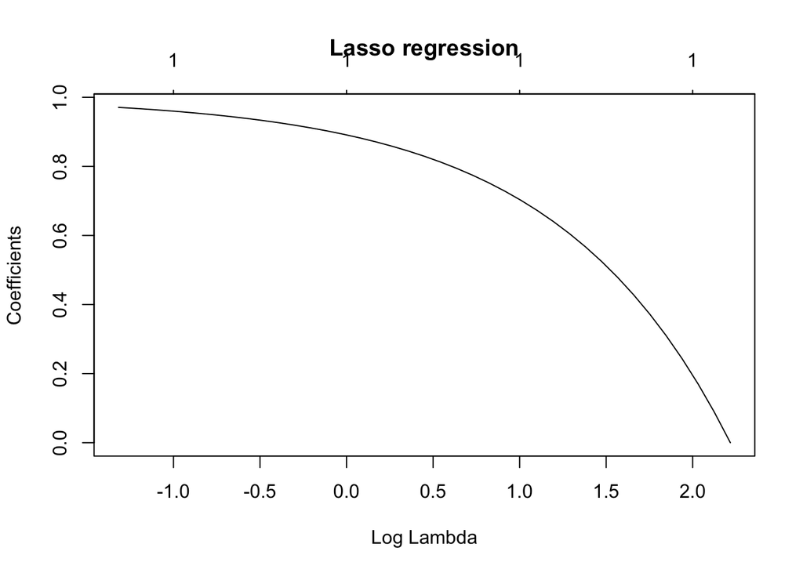

```r
# convert data to matrix type
trainX <- as.matrix(training.data[, -1])
testX <- as.matrix(test.data[, -1])
trainY <- training.data$MEDV

lasso <- glmnet(x = trainX, y = trainY, alpha = 1)
plot(lasso, xvar = "lambda", main = "Lasso regression")
```

```r
library(caret)
set.seed(0)
train_control <- trainControl(method="cv", number=5)

glmnet.lasso <- train(MEDV ~ ., data = training.data, method = "glmnet",
                      trControl = train_control,
                      tuneGrid = expand.grid(alpha = 1,lambda = seq(0.001,0.1,by = 0.001)))

glmnet.lasso
```

```
## glmnet
##
## 354 samples
##  12 predictor
##
## No pre-processing
## Resampling: Cross-Validated (5 fold)
## Summary of sample sizes: 284, 283, 282, 283, 284
## Resampling results across tuning parameters:
##
##   lambda  RMSE      Rsquared   MAE
##   0.001   4.823177  0.7265029  3.404341
##   0.002   4.823177  0.7265029  3.404341
##   0.003   4.823177  0.7265029  3.404341
##   0.004   4.823177  0.7265029  3.404341
##   0.005   4.823177  0.7265029  3.404341
##   0.006   4.822835  0.7265420  3.403851
##   0.007   4.822260  0.7266134  3.402984
##   0.008   4.821577  0.7266872  3.401593
##   0.009   4.820967  0.7267512  3.400247
##   0.010   4.820398  0.7268119  3.398977
##   0.011   4.819691  0.7268910  3.397696
##   0.012   4.818932  0.7269774  3.396482
##   0.013   4.818171  0.7270642  3.395272
##   0.014   4.817432  0.7271485  3.394071
##   0.015   4.816678  0.7272354  3.392829
##   0.016   4.815945  0.7273206  3.391670
##   0.017   4.815259  0.7273993  3.390571
##   0.018   4.814595  0.7274759  3.389502
##   0.019   4.813933  0.7275529  3.388503
##   0.020   4.813268  0.7276301  3.387515
##   0.021   4.812621  0.7277055  3.386575
##   0.022   4.812005  0.7277781  3.385783
##   0.023   4.811398  0.7278506  3.385064
##   0.024   4.810794  0.7279225  3.384324
##   0.025   4.810213  0.7279897  3.383556
##   0.026   4.809648  0.7280555  3.382805
##   0.027   4.809095  0.7281204  3.382091
##   0.028   4.808560  0.7281835  3.381383
##   0.029   4.808048  0.7282440  3.380677
```

[output cut: 60 more lines]

```
##   0.090   4.812415  0.7283206  3.367084
##   0.091   4.812997  0.7282693  3.367145
##   0.092   4.813591  0.7282167  3.367205
##   0.093   4.814196  0.7281627  3.367266
##   0.094   4.814815  0.7281074  3.367327
##   0.095   4.815427  0.7280528  3.367420
##   0.096   4.816048  0.7279973  3.367511
##   0.097   4.816683  0.7279405  3.367653
##   0.098   4.817333  0.7278824  3.367803
##   0.099   4.817996  0.7278230  3.367954
##   0.100   4.818670  0.7277622  3.368162
##
## Tuning parameter 'alpha' was held constant at a value of 1
## RMSE was used to select the optimal model using the smallest value.
## The final values used for the model were alpha = 1 and lambda = 0.057.
```

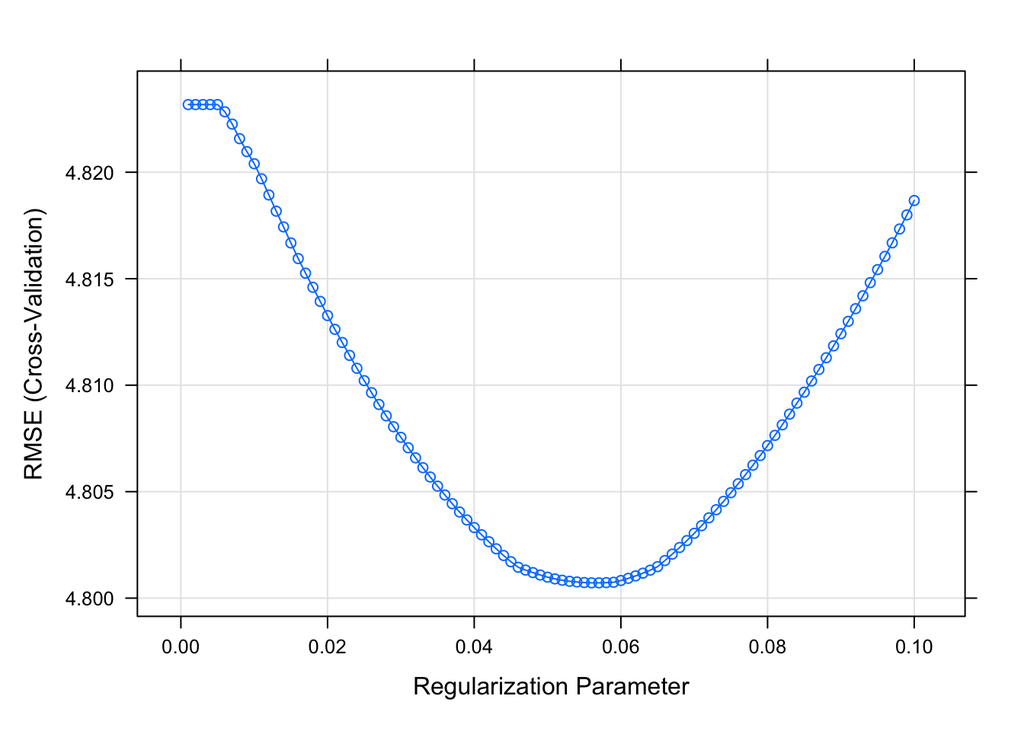

```r
plot(glmnet.lasso)
```

```r
# best parameter
glmnet.lasso$bestTune
```

```
##    alpha lambda
## 57     1  0.057
```

```r
# best coefficient
lasso.model <- coef(glmnet.lasso$finalModel, glmnet.lasso$bestTune$lambda)
lasso.model
```

```
## 13 x 1 sparse Matrix of class "dgCMatrix"
##                        s1
## (Intercept)  44.287248284
## CRIM         -0.037393423
## ZN            0.037935753
## INDUS         .
## CHAS          2.751585076
## NOX         -18.729957327
## RM            3.490115362
## AGE           .
## DIS          -1.531828633
## RAD           0.212758918
## TAX          -0.009231802
## PTRATIO      -1.043861875
## LSTAT        -0.568531662
```

```r
# prediction on test data
yhat.lasso <- predict(glmnet.lasso, s = glmnet.lasso$bestTune, test.data)
# RMSE for test data
error.test.lasso <- yhat.lasso - test.data$MEDV
rmse.test.lasso <- sqrt(mean(error.test.lasso^2))
rmse.test.lasso
```

```
## [1] 5.14288
```

## Compare the models obtained in the above three steps. Create lift charts on test data for all models and comment on that.

RMSE MLR: 5.1607

RMSE STEP: 5.299994

RMSE Lasso: 5.1429

From the lift charts, the models differ slightly.

In the top 40%:

53% of records captured in the top 40% of the stepwise regression model.

In the top 80%:

87.2% of records captured in the top 80% of the MLR model.

87.0% of records captured in the top 80% of the stepwise regression model.

87.1% of records captured in the top 80% of the lasso regression model.

```r
library(gains)

# getting Lift chart on test data for multiple regression
gain <- gains(test.data$MEDV, yhat)
gain
```

```
## Depth                            Cume   Cume Pct                     Mean
##  of           Cume     Mean      Mean   of Total    Lift   Cume     Model
## File     N      N      Resp      Resp      Resp    Index   Lift     Score
## -------------------------------------------------------------------------
##   10    15     15     39.69     39.69      17.1%     173    173     36.45
##   20    15     30     30.76     35.23      30.3%     134    154     30.66
##   30    15     45     26.94     32.46      41.9%     117    142     27.02
##   39    15     60     24.66     30.51      52.5%     108    133     24.17
##   50    16     76     22.39     28.80      62.8%      98    126     22.08
##   60    15     91     19.97     27.35      71.4%      87    119     20.29
##   70    15    106     20.03     26.31      80.0%      87    115     18.71
##   80    15    121     16.69     25.12      87.2%      73    110     17.04
##   89    15    136     16.55     24.17      94.3%      72    105     14.75
##  100    16    152     12.40     22.93     100.0%      54    100      9.88
```

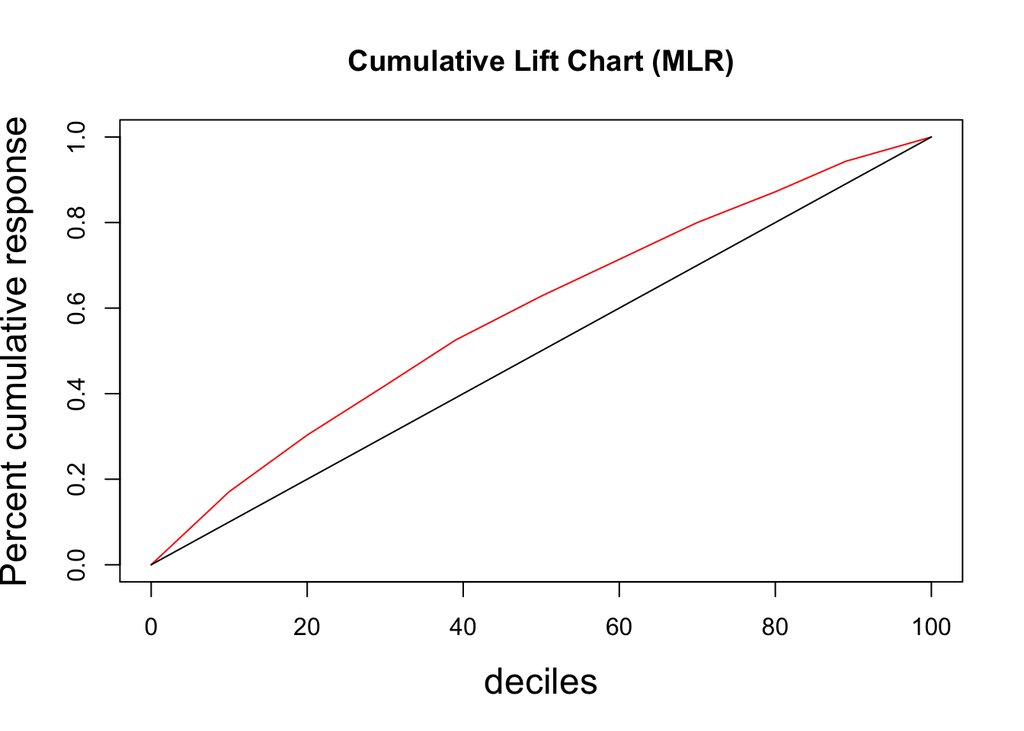

```r
x <- c(0, gain$depth)
pred.y <- c(0, gain$cume.pct.of.total)
avg.y <- c(0, gain$depth/100)
plot(x, pred.y, main = "Cumulative Lift Chart (MLR)", xlab = "deciles",
     ylab = "Percent cumulative response", type = "l", col = "red", cex.lab = 1.5)
lines(x, avg.y, type = "l")
```

```r
# getting Lift chart on test data for stepwise regression
gain <- gains(test.data$MEDV, yhatSW)
gain
```

```
## Depth                            Cume   Cume Pct                     Mean
##  of           Cume     Mean      Mean   of Total    Lift   Cume     Model
## File     N      N      Resp      Resp      Resp    Index   Lift     Score
## -------------------------------------------------------------------------
##   10    15     15     39.69     39.69      17.1%     173    173     36.50
##   20    15     30     30.76     35.23      30.3%     134    154     30.70
##   30    15     45     26.94     32.46      41.9%     117    142     27.11
##   39    15     60     25.68     30.77      53.0%     112    134     24.20
##   50    16     76     20.64     28.64      62.4%      90    125     22.15
##   60    15     91     20.27     27.26      71.2%      88    119     20.38
##   70    15    106     19.39     26.14      79.5%      85    114     18.80
##   80    15    121     17.39     25.06      87.0%      76    109     17.14
##   89    15    136     16.31     24.09      94.0%      71    105     14.78
##  100    16    152     13.08     22.93     100.0%      57    100     10.34
```

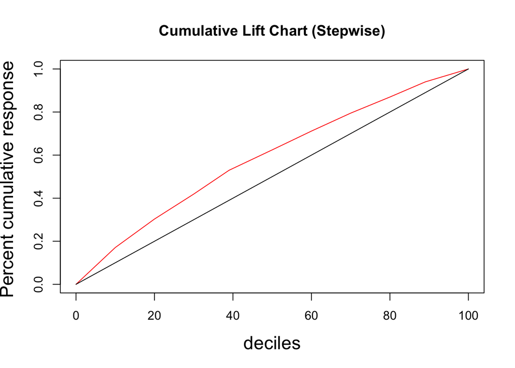

```r
x <- c(0, gain$depth)
pred.y <- c(0, gain$cume.pct.of.total)
avg.y <- c(0, gain$depth/100)
plot(x, pred.y, main = "Cumulative Lift Chart (Stepwise)", xlab = "deciles",
     ylab = "Percent cumulative response ", type = "l", col = "red", cex.lab = 1.5)
lines(x, avg.y, type = "l")
```

```r
##getting Lift chart on test data for lasso regression
gain <- gains(test.data$MEDV, yhat.lasso)
gain
```

```
## Depth                            Cume   Cume Pct                     Mean
##  of           Cume     Mean      Mean   of Total    Lift   Cume     Model
## File     N      N      Resp      Resp      Resp    Index   Lift     Score
## -------------------------------------------------------------------------
##   10    15     15     40.01     40.01      17.2%     174    174     36.15
##   20    15     30     30.45     35.23      30.3%     133    154     30.56
##   30    15     45     26.94     32.46      41.9%     117    142     27.13
##   39    15     60     25.68     30.77      53.0%     112    134     24.29
##   50    16     76     21.65     28.85      62.9%      94    126     22.33
##   60    15     91     20.95     27.55      71.9%      91    120     20.40
##   70    15    106     17.60     26.14      79.5%      77    114     18.93
##   80    15    121     17.71     25.09      87.1%      77    109     17.31
##   89    15    136     16.11     24.10      94.0%      70    105     15.09
##  100    16    152     12.99     22.93     100.0%      57    100     10.48
```

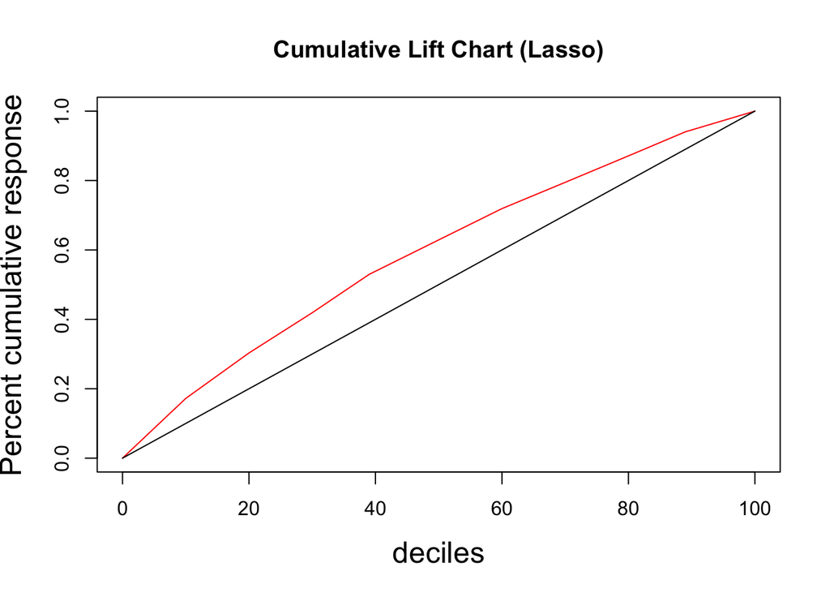

```r
x <- c(0, gain$depth)
pred.y <- c(0, gain$cume.pct.of.total)
avg.y <- c(0, gain$depth/100)
plot(x, pred.y, main = "Cumulative Lift Chart (Lasso)", xlab = "deciles",
     ylab = "Percent cumulative response", type = "l", col = "red", cex.lab = 1.5)
lines(x, avg.y, type = "l")
```

```r
## import original file and functions
bos <- read.csv("~/Desktop/MATH 440 - Statistical Learning/BostonHousing.csv")
source("~/Desktop/MATH 440 - Statistical Learning/myfunctions.R")

## removing MEDV and keeping CAT..MEDV
keeps <- c("CRIM", "ZN", "INDUS", "CHAS", "NOX", "RM", "AGE", "DIS", "RAD","TAX", "PTRATIO", "LSTAT", "CAT..MEDV")
bos<- bos[keeps]
```

## Partition the data into training, validation, and test data sets. Create a logistic regression model on training data using all regressors and report the performance of that model on test data. What is the effect on the odds of houses having high median value when the per capita crime rate of a town is increased by 0.1?

Logistic Regression Model: $y = 3.0664 + 0.0649CRIM + 0.0374ZN - 0.1686INDUS + 0.5484CHAS + 0.8802NOX + 1.9310RM + 0.0132AGE - 0.6124DIS + 0.2935RAD - 0.0096TAX - 0.6011PTRATIO - 0.5328LSTAT$

RMSE on test data: 8.6652 From confusion matrix: Accuracy: 0.9412, Kappa: 0.7657, Sensitivity: 0.7500, Specificity: 0.9767

For every 0.1 unit increase in per capita crime rate, the odds of houses having high median value increases multiplicatively by 1.0065 times when other predictors remain constant.

```r
#partition the data into training, validation, and test sets
RNGkind (sample.kind = "Rounding")
set.seed(0) ## set seed so that you get same partition each time
p2 <- partition.3(bos, 0.7,0.2) ## creating 70:20:10 partition
training.data <- p2$data.train
test.data <- p2$data.test
validation.data <- p2$data.val

#create a logistic model on training data
logistic.model <- glm(CAT..MEDV ~ ., family = binomial(link='logit'), data=training.data)
summary(logistic.model)
```

```
##
## Call:
## glm(formula = CAT..MEDV ~ ., family = binomial(link = "logit"),
##     data = training.data)
##
## Deviance Residuals:
##      Min        1Q    Median        3Q       Max
## -2.82971  -0.09089  -0.02630  -0.00189   2.39111
##
## Coefficients:
##              Estimate Std. Error z value Pr(>|z|)
## (Intercept)  3.066446   8.365105   0.367 0.713935
## CRIM         0.064884   0.065718   0.987 0.323495
## ZN           0.037354   0.017893   2.088 0.036829 *
## INDUS       -0.168604   0.125097  -1.348 0.177729
## CHAS         0.548408   1.023390   0.536 0.592046
## NOX          0.880153   7.262469   0.121 0.903539
## RM           1.931016   0.691410   2.793 0.005224 **
## AGE          0.013236   0.018083   0.732 0.464208
## DIS         -0.612431   0.271230  -2.258 0.023947 *
## RAD          0.293530   0.131918   2.225 0.026075 *
## TAX         -0.009617   0.005802  -1.657 0.097430 .
## PTRATIO     -0.601080   0.220253  -2.729 0.006352 **
## LSTAT       -0.532823   0.153146  -3.479 0.000503 ***
## ---
## Signif. codes:  0 '***' 0.001 '**' 0.01 '*' 0.05 '.' 0.1 ' ' 1
##
## (Dispersion parameter for binomial family taken to be 1)
##
##     Null deviance: 315.758  on 353  degrees of freedom
## Residual deviance:  83.727  on 341  degrees of freedom
## AIC: 109.73
##
## Number of Fisher Scoring iterations: 9
```

```r
#performance of model on test data
yhat = predict(logistic.model, newdata = data.frame(test.data))
## RMSE for test data
error.test <- test.data$CAT..MEDV - yhat
rmse.test <- sqrt(mean(error.test^2))
rmse.test
```

```
## [1] 8.665175
```

```r
##confusion matrix
pred.prob.test <- predict(logistic.model, newdata = test.data, type = "response")
pred.y.test <- ifelse(pred.prob.test > 0.5, 1, 0) # using cutoff = 0.5
confusionMatrix(as.factor(pred.y.test), as.factor(test.data$CAT..MEDV),positive = "1")
```

```
## Confusion Matrix and Statistics
##
##           Reference
## Prediction  0  1
##          0 42  2
##          1  1  6
##
##                Accuracy : 0.9412
##                  95% CI : (0.8376, 0.9877)
##     No Information Rate : 0.8431
##     P-Value [Acc > NIR] : 0.03138
##
##                   Kappa : 0.7657
##
##  Mcnemar's Test P-Value : 1.00000
##
##             Sensitivity : 0.7500
##             Specificity : 0.9767
##          Pos Pred Value : 0.8571
##          Neg Pred Value : 0.9545
##              Prevalence : 0.1569
##          Detection Rate : 0.1176
##    Detection Prevalence : 0.1373
##       Balanced Accuracy : 0.8634
##
##        'Positive' Class : 1
##
```

```r
## effect on the odds of houses having high median value when CRIM increased by 0.1
exp(0.064884*0.1)
```

```
## [1] 1.006509
```

## Considering “1” as the important class, conduct a search for the best cut-off value with the objective of striking a balance between sensitivity and specificity. Report the performance of the optimal model found in this search.

Best cut-off value: 0.3

Accuracy: 0.9412, Kappa: 0.7884, Sensitivity: 0.8750, Specificity: 0.9535

```r
pred.prob.test <- predict(logistic.model, newdata = test.data, type = "response")
pred.y.test <- ifelse(pred.prob.test > 0.1, 1, 0) # using cutoff = 0.1
confusionMatrix(as.factor(pred.y.test), as.factor(test.data$CAT..MEDV),positive = "1")
```

```
## Confusion Matrix and Statistics
##
##           Reference
## Prediction  0  1
##          0 39  0
##          1  4  8
##
##                Accuracy : 0.9216
##                  95% CI : (0.8112, 0.9782)
##     No Information Rate : 0.8431
##     P-Value [Acc > NIR] : 0.08116
##
##                   Kappa : 0.7536
##
##  Mcnemar's Test P-Value : 0.13361
##
##             Sensitivity : 1.0000
##             Specificity : 0.9070
##          Pos Pred Value : 0.6667
##          Neg Pred Value : 1.0000
##              Prevalence : 0.1569
##          Detection Rate : 0.1569
##    Detection Prevalence : 0.2353
##       Balanced Accuracy : 0.9535
##
##        'Positive' Class : 1
##
```

```r
pred.prob.test <- predict(logistic.model, newdata = test.data, type = "response")
pred.y.test <- ifelse(pred.prob.test > 0.2, 1, 0) # using cutoff = 0.2
confusionMatrix(as.factor(pred.y.test), as.factor(test.data$CAT..MEDV),positive = "1")
```

```
## Confusion Matrix and Statistics
##
##           Reference
## Prediction  0  1
##          0 40  1
##          1  3  7
##
##                Accuracy : 0.9216
##                  95% CI : (0.8112, 0.9782)
##     No Information Rate : 0.8431
##     P-Value [Acc > NIR] : 0.08116
##
##                   Kappa : 0.7309
##
##  Mcnemar's Test P-Value : 0.61708
##
##             Sensitivity : 0.8750
##             Specificity : 0.9302
##          Pos Pred Value : 0.7000
##          Neg Pred Value : 0.9756
##              Prevalence : 0.1569
##          Detection Rate : 0.1373
##    Detection Prevalence : 0.1961
##       Balanced Accuracy : 0.9026
##
##        'Positive' Class : 1
##
```

```r
pred.prob.test <- predict(logistic.model, newdata = test.data, type = "response")
pred.y.test <- ifelse(pred.prob.test > 0.3, 1, 0) # using cutoff = 0.3
confusionMatrix(as.factor(pred.y.test), as.factor(test.data$CAT..MEDV),positive = "1")
```

```
## Confusion Matrix and Statistics
##
##           Reference
## Prediction  0  1
##          0 41  1
##          1  2  7
##
##                Accuracy : 0.9412
##                  95% CI : (0.8376, 0.9877)
##     No Information Rate : 0.8431
##     P-Value [Acc > NIR] : 0.03138
##
##                   Kappa : 0.7884
##
##  Mcnemar's Test P-Value : 1.00000
##
##             Sensitivity : 0.8750
##             Specificity : 0.9535
##          Pos Pred Value : 0.7778
##          Neg Pred Value : 0.9762
##              Prevalence : 0.1569
##          Detection Rate : 0.1373
##    Detection Prevalence : 0.1765
##       Balanced Accuracy : 0.9142
##
##        'Positive' Class : 1
##
```

```r
pred.prob.test <- predict(logistic.model, newdata = test.data, type = "response")
pred.y.test <- ifelse(pred.prob.test > 0.4, 1, 0) # using cutoff = 0.4
confusionMatrix(as.factor(pred.y.test), as.factor(test.data$CAT..MEDV),positive = "1")
```

```
## Confusion Matrix and Statistics
##
##           Reference
## Prediction  0  1
##          0 42  2
##          1  1  6
##
##                Accuracy : 0.9412
##                  95% CI : (0.8376, 0.9877)
##     No Information Rate : 0.8431
##     P-Value [Acc > NIR] : 0.03138
##
##                   Kappa : 0.7657
##
##  Mcnemar's Test P-Value : 1.00000
##
##             Sensitivity : 0.7500
##             Specificity : 0.9767
##          Pos Pred Value : 0.8571
##          Neg Pred Value : 0.9545
##              Prevalence : 0.1569
##          Detection Rate : 0.1176
##    Detection Prevalence : 0.1373
##       Balanced Accuracy : 0.8634
##
##        'Positive' Class : 1
##
```

```r
pred.prob.test <- predict(logistic.model, newdata = test.data, type = "response")
pred.y.test <- ifelse(pred.prob.test > 0.5, 1, 0) # using cutoff = 0.5
confusionMatrix(as.factor(pred.y.test), as.factor(test.data$CAT..MEDV),positive = "1")
```

```
## Confusion Matrix and Statistics
##
##           Reference
## Prediction  0  1
##          0 42  2
##          1  1  6
##
##                Accuracy : 0.9412
##                  95% CI : (0.8376, 0.9877)
##     No Information Rate : 0.8431
##     P-Value [Acc > NIR] : 0.03138
##
##                   Kappa : 0.7657
##
##  Mcnemar's Test P-Value : 1.00000
##
##             Sensitivity : 0.7500
##             Specificity : 0.9767
##          Pos Pred Value : 0.8571
##          Neg Pred Value : 0.9545
##              Prevalence : 0.1569
##          Detection Rate : 0.1176
##    Detection Prevalence : 0.1373
##       Balanced Accuracy : 0.8634
##
##        'Positive' Class : 1
##
```

```r
pred.prob.test <- predict(logistic.model, newdata = test.data, type = "response")
pred.y.test <- ifelse(pred.prob.test > 0.6, 1, 0) # using cutoff = 0.6
confusionMatrix(as.factor(pred.y.test), as.factor(test.data$CAT..MEDV),positive = "1")
```

```
## Confusion Matrix and Statistics
##
##           Reference
## Prediction  0  1
##          0 42  3
##          1  1  5
##
##                Accuracy : 0.9216
##                  95% CI : (0.8112, 0.9782)
##     No Information Rate : 0.8431
##     P-Value [Acc > NIR] : 0.08116
##
##                   Kappa : 0.6699
##
##  Mcnemar's Test P-Value : 0.61708
##
##             Sensitivity : 0.62500
##             Specificity : 0.97674
##          Pos Pred Value : 0.83333
##          Neg Pred Value : 0.93333
##              Prevalence : 0.15686
##          Detection Rate : 0.09804
##    Detection Prevalence : 0.11765
##       Balanced Accuracy : 0.80087
##
##        'Positive' Class : 1
##
```

```r
pred.prob.test <- predict(logistic.model, newdata = test.data, type = "response")
pred.y.test <- ifelse(pred.prob.test > 0.7, 1, 0) # using cutoff = 0.7
confusionMatrix(as.factor(pred.y.test), as.factor(test.data$CAT..MEDV),positive = "1")
```

```
## Confusion Matrix and Statistics
##
##           Reference
## Prediction  0  1
##          0 43  3
##          1  0  5
##
##                Accuracy : 0.9412
##                  95% CI : (0.8376, 0.9877)
##     No Information Rate : 0.8431
##     P-Value [Acc > NIR] : 0.03138
##
##                   Kappa : 0.7376
##
##  Mcnemar's Test P-Value : 0.24821
##
##             Sensitivity : 0.62500
##             Specificity : 1.00000
##          Pos Pred Value : 1.00000
##          Neg Pred Value : 0.93478
##              Prevalence : 0.15686
##          Detection Rate : 0.09804
##    Detection Prevalence : 0.09804
##       Balanced Accuracy : 0.81250
##
##        'Positive' Class : 1
##
```

```r
pred.prob.test <- predict(logistic.model, newdata = test.data, type = "response")
pred.y.test <- ifelse(pred.prob.test > 0.8, 1, 0) # using cutoff = 0.8
confusionMatrix(as.factor(pred.y.test), as.factor(test.data$CAT..MEDV),positive = "1")
```

```
## Confusion Matrix and Statistics
##
##           Reference
## Prediction  0  1
##          0 43  4
##          1  0  4
##
##                Accuracy : 0.9216
##                  95% CI : (0.8112, 0.9782)
##     No Information Rate : 0.8431
##     P-Value [Acc > NIR] : 0.08116
##
##                   Kappa : 0.6277
##
##  Mcnemar's Test P-Value : 0.13361
##
##             Sensitivity : 0.50000
##             Specificity : 1.00000
##          Pos Pred Value : 1.00000
##          Neg Pred Value : 0.91489
##              Prevalence : 0.15686
##          Detection Rate : 0.07843
##    Detection Prevalence : 0.07843
##       Balanced Accuracy : 0.75000
##
##        'Positive' Class : 1
##
```

```r
pred.prob.test <- predict(logistic.model, newdata = test.data, type = "response")
pred.y.test <- ifelse(pred.prob.test > 0.9, 1, 0) # using cutoff = 0.9
confusionMatrix(as.factor(pred.y.test), as.factor(test.data$CAT..MEDV),positive = "1")
```

```
## Confusion Matrix and Statistics
##
##           Reference
## Prediction  0  1
##          0 43  6
##          1  0  2
##
##                Accuracy : 0.8824
##                  95% CI : (0.7613, 0.9556)
##     No Information Rate : 0.8431
##     P-Value [Acc > NIR] : 0.29240
##
##                   Kappa : 0.3598
##
##  Mcnemar's Test P-Value : 0.04123
##
##             Sensitivity : 0.25000
##             Specificity : 1.00000
##          Pos Pred Value : 1.00000
##          Neg Pred Value : 0.87755
##              Prevalence : 0.15686
##          Detection Rate : 0.03922
##    Detection Prevalence : 0.03922
##       Balanced Accuracy : 0.62500
##
##        'Positive' Class : 1
##
```